# Assignment 2

Ufuk Cem Birbiri

15.11.2022

# PART-1

### Comparison of imputation methods

Installing libraries

```r
#install.packages("VIM")
library(VIM)
data(SBS5242)
XNA <- SBS5242
```

Before starting the questions, let’s investigate the dataset.

```r
head(XNA)
```

```
##            PW       BWS_F      Umsatz         PERSA       BEZWD     BEZWDVK
## 1 43888.85242 35081.07414 3737.974701 11815.3610831 37577.19455 379.0521485
## 2  1449.40170  1239.13170  120.099200     5.9457950  1251.43080   8.6653528
## 3  1009.61541   944.93722   79.832300   163.2859277   857.75827   4.2969994
## 4  1218.17072   942.29390  104.851729     1.9011026  1063.73052  20.4941952
## 5   517.36342   450.46195   41.326691    18.0060038   448.09227   2.0590045
## 6    67.19103    44.91809    5.003297    -0.6017785    62.71034  -0.2673511
##       BESCH         USB      ISACH
## 1 310.09482 30.48368699 6575.33408
## 2  18.47358 -0.41414050   58.02441
## 3  24.73831  0.35008017   12.33191
## 4  30.44422 -0.37563076  513.91041
## 5  20.18175 -0.09648481   21.44578
## 6  13.85199 -0.68410116   25.90378
```

And we can see the dimension:

```r
dim(XNA)
```

```
## [1] 262   9
```

The dimensoin of the dataset is (262, 9) . We can also display the column names:

```r
colnames(XNA)
```

```
## [1] "PW"      "BWS_F"   "Umsatz"  "PERSA"   "BEZWD"   "BEZWDVK" "BESCH"
## [8] "USB"     "ISACH"
```

### Question 1

- Visualize the missing values with the function **aggr** of the **VIM** package and compute the global percentage of missing values in the dataset.

The function “aggr” measures the number of missing entries in each feature and for certain combinations of features (which tend to be missing simultaneously).

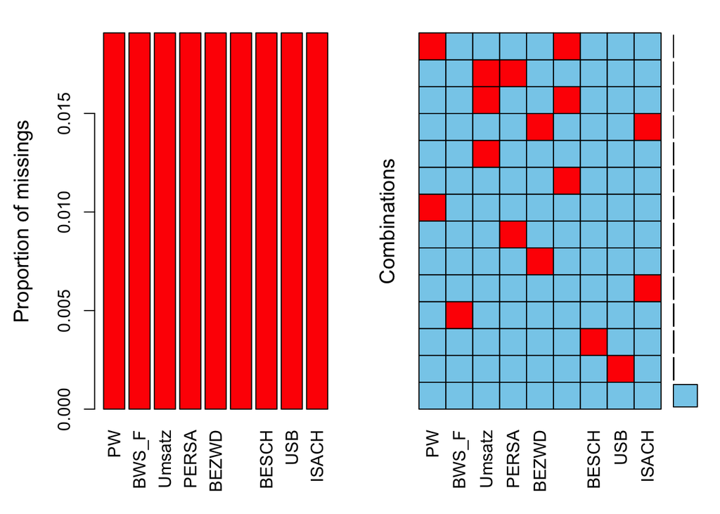

```r
## Finding missing values
a <- aggr(XNA)
```

The count of missing values and the percantage is shown in below:

```r
summary(a)
```

```
##
##  Missings per variable:
##  Variable Count
##        PW     5
##     BWS_F     5
##    Umsatz     5
##     PERSA     5
##     BEZWD     5
##   BEZWDVK     5
##     BESCH     5
##       USB     5
##     ISACH     5
##
##  Missings in combinations of variables:
##       Combinations Count    Percent
##  0:0:0:0:0:0:0:0:0   221 84.3511450
##  0:0:0:0:0:0:0:0:1     4  1.5267176
##  0:0:0:0:0:0:0:1:0     5  1.9083969
##  0:0:0:0:0:0:1:0:0     5  1.9083969
##  0:0:0:0:0:1:0:0:0     3  1.1450382
##  0:0:0:0:1:0:0:0:0     4  1.5267176
##  0:0:0:0:1:0:0:0:1     1  0.3816794
##  0:0:0:1:0:0:0:0:0     4  1.5267176
##  0:0:1:0:0:0:0:0:0     3  1.1450382
##  0:0:1:0:0:1:0:0:0     1  0.3816794
##  0:0:1:1:0:0:0:0:0     1  0.3816794
##  0:1:0:0:0:0:0:0:0     5  1.9083969
##  1:0:0:0:0:0:0:0:0     4  1.5267176
##  1:0:0:0:0:1:0:0:0     1  0.3816794
```

### Question 2

- Introduce 30% synthetic missing values in the dataset. You can use the function **synthetic_MCAR** (defined below) or create your own function. Explain why the synthetic missing values introduced as such are MCAR.

With Mcar function, the values are randomly missing from your dataset. Missing data values do not relate to any other data in the dataset and there is no pattern to the actual values of the missing data themselves.

```r
#Introduce 30% synthetic missing values in the dataset.

library(FactoMineR)
n <- dim(XNA)[1]
d <- dim(XNA)[2]

prop.miss <- 0.3
nb.miss <- floor(n*d*prop.miss)
missing_pattern.mcar <- matrix(runif(n*d,0,1) < 0.3,nrow=n,ncol=d)
XNA.mcar <- XNA
XNA.mcar[missing_pattern.mcar] <- NA
head(XNA.mcar)
```

```
##          PW      BWS_F     Umsatz         PERSA      BEZWD     BEZWDVK
## 1        NA 35081.0741         NA 11815.3610831         NA 379.0521485
## 2 1449.4017         NA 120.099200     5.9457950 1251.43080          NA
## 3 1009.6154   944.9372  79.832300   163.2859277  857.75827   4.2969994
## 4 1218.1707   942.2939         NA            NA 1063.73052  20.4941952
## 5  517.3634   450.4620  41.326691    18.0060038  448.09227   2.0590045
## 6        NA         NA   5.003297    -0.6017785   62.71034  -0.2673511
##       BESCH         USB     ISACH
## 1 310.09482 30.48368699        NA
## 2  18.47358 -0.41414050  58.02441
## 3  24.73831  0.35008017  12.33191
## 4        NA -0.37563076 513.91041
## 5        NA -0.09648481        NA
## 6  13.85199 -0.68410116  25.90378
```

```r
XNA.mcar <- as.matrix(as.data.frame(XNA.mcar))
```

### Question 3

- Compare three imputation methods (mean imputation, another single imputation, multiple imputation) by computing the MSE for the synthetic missing values.

#### 3.1 Imputation by the mean

```r
ImputeMean <- function(tab){
  m <- apply(tab, 2, mean, na.rm = TRUE)
  tab <- sapply(1:ncol(tab), function(x) ifelse(is.na(tab[,x]), m[x], tab[,x]))
  tab <- as.data.frame(tab)
  return(tab)
}

XNA.mean <- ImputeMean(XNA.mcar)
head(XNA.mean)
```

```
##          V1         V2          V3            V4         V5          V6
## 1 2221.3646 35081.0741 1957.274783 11815.3610831 1340.39222 379.0521485
## 2 1449.4017  1499.6782  120.099200     5.9457950 1251.43080  18.0281220
## 3 1009.6154   944.9372   79.832300   163.2859277  857.75827   4.2969994
## 4 1218.1707   942.2939 1957.274783  2176.5518606 1063.73052  20.4941952
## 5  517.3634   450.4620   41.326691    18.0060038  448.09227   2.0590045
## 6 2221.3646  1499.6782    5.003297    -0.6017785   62.71034  -0.2673511
##          V7          V8        V9
## 1 310.09482 30.48368699 181.39888
## 2  18.47358 -0.41414050  58.02441
## 3  24.73831  0.35008017  12.33191
## 4  20.29210 -0.37563076 513.91041
## 5  20.29210 -0.09648481 181.39888
## 6  13.85199 -0.68410116  25.90378
```

#### 3.2 Imputation with softImpute

For softImpute, the main arguments are the following ones:

- `x`: the dataset with missing values (matrix).
- `rank.max`: the restricted rank of the solution, which should not be bigger than min(dim(x))-1.
- `lambda`: the nuclear-norm regularization parameter.

```r
library(softImpute)
sft <- softImpute(x = XNA.mcar, rank.max = 4, lambda = 0.001)
XNA.sft <- sft$u %*% diag(sft$d) %*% t(sft$v) # compute the factorization
XNA.sft[which(!is.na(XNA.mcar))] <- XNA.mcar[which(!is.na(XNA.mcar))] # replace missing values by computed values
head(XNA.sft)
```

```
##               [,1]        [,2]          [,3]          [,4]        [,5]
## [1,] -14710.298336 35081.07414 -17889.097343 11815.3610831 25371.78303
## [2,]   1449.401700  1321.11375    120.099200     5.9457950  1251.43080
## [3,]   1009.615413   944.93722     79.832300   163.2859277   857.75827
## [4,]   1218.170724   942.29390    665.314820  -745.4634181  1063.73052
## [5,]    517.363418   450.46195     41.326691    18.0060038   448.09227
## [6,]      9.982984    77.25625      5.003297    -0.6017785    62.71034
##             [,6]       [,7]        [,8]       [,9]
## [1,] 379.0521485 310.094825 30.48368699 1994.07587
## [2,]  11.7574102  18.473580 -0.41414050   58.02441
## [3,]   4.2969994  24.738311  0.35008017   12.33191
## [4,]  20.4941952  13.831694 -0.37563076  513.91041
## [5,]   2.0590045   5.895403 -0.09648481   43.67699
## [6,]  -0.2673511  13.851994 -0.68410116   25.90378
```

#### 3.3 Imputation with multiple imputation

The parameters of the mice function is:

1. `data`: the dataset with missing values.
2. `m`: number of multiple imputations.

```r
library(mice)
nb_imputeddataset <- 5
mice_mice <- mice(data = matrix(XNA.mcar,nrow=n,ncol=d), m = nb_imputeddataset)
```

```r
IMP <- 0
for (i in 1:nb_imputeddataset) { IMP <- IMP + mice::complete(mice_mice, i)}
XNA.mice  <-  IMP/nb_imputeddataset  #5 is the default number of multiple imputations
head(XNA.mice)
```

```
##           V1         V2          V3            V4          V5          V6
## 1 16664.7487 35081.0741 8624.767673 11815.3610831 16335.55064 379.0521485
## 2  1449.4017  1342.0891  120.099200     5.9457950  1251.43080  13.5533845
## 3  1009.6154   944.9372   79.832300   163.2859277   857.75827   4.2969994
## 4  1218.1707   942.2939 1413.737957    18.7228408  1063.73052  20.4941952
## 5   517.3634   450.4620   41.326691    18.0060038   448.09227   2.0590045
## 6   117.0670   263.3299    5.003297    -0.6017785    62.71034  -0.2673511
##           V7          V8        V9
## 1 310.094825 30.48368699 920.92941
## 2  18.473580 -0.41414050  58.02441
## 3  24.738311  0.35008017  12.33191
## 4   9.269997 -0.37563076 513.91041
## 5  12.563055 -0.09648481  13.02140
## 6  13.851994 -0.68410116  25.90378
```

```r
MSE <- function(X1, X2){

  return(mean( (X1 - X2)^2 ,na.rm=T)^2 )

  }
```

```r
mse_mean <- MSE(XNA, as.matrix(XNA.mean))
mse_mean
```

```
## [1] 2.268035e+14
```

```r
mse_soft <- MSE(XNA, as.matrix(XNA.sft))
mse_soft
```

```
## [1] 2.29494e+14
```

```r
mse_mice <- MSE(XNA, as.matrix(XNA.mice))
mse_mice
```

```
## [1] 1.229615e+14
```

The mean squared error is lowest in multiple imputation method.

### Question 4

- To analyse the stochasticity implied by the introduction of missing values, repeat the procedure (introduction of synthetic missing values and imputation) several times and plot the distribution of the MSEs by showing a boxplot.

```r
#30% missing value
prop.miss <- 0.3

mean_impt = c()
soft_impt = c()
multip_impt = c()
index = c()

for (i in 1:1) {

  #Introduce missing values and percentage
  nb.miss <- floor(n*d*prop.miss)
  missing_pattern.mcar <- matrix(runif(n*d,0,1) < 0.3,nrow=n,ncol=d)
  XNA.mcar <- XNA
  XNA.mcar[missing_pattern.mcar] <- NA
  XNA.mcar <- as.matrix(as.data.frame(XNA.mcar))

  #Mean imputation:
  XNA.mean <- ImputeMean(XNA.mcar)

  #calculate MSE
  mse_mean <- MSE(XNA, as.matrix(XNA.mean))
  mean_impt <- append(mean_impt, mse_mean)

  #Soft Imputation:
  sft <- softImpute(x = XNA.mcar, rank.max = 4, lambda = 0.001)
  XNA.sft <- sft$u %*% diag(sft$d) %*% t(sft$v)
  XNA.sft[which(!is.na(XNA.mcar))] <- XNA.mcar[which(!is.na(XNA.mcar))]

  #calculate MSE
  mse_soft <- MSE(XNA, as.matrix(XNA.sft))
  soft_impt <- append(soft_impt, mse_soft)

  #Multiple imputation
  nb_imputeddataset <- 5
  mice_mice <- mice(data = matrix(XNA.mcar,nrow=n,ncol=d), m = nb_imputeddataset)
  IMP <- 0
  for (i in 1:nb_imputeddataset) { IMP <- IMP + mice::complete(mice_mice, i)}
  XNA.mice  <-  IMP/nb_imputeddataset  #5 is the default number of multiple imputations

  #calculate MSE
  mse_mice <- MSE(XNA, as.matrix(XNA.mice))
  multip_impt <- append(multip_impt, mse_mice)

  #Index:
  #I also save the index to use it in the box-plot later as the x-axis
  index <- append(index, i)
}
```

Create the data-frame:

```r
data <- data.frame(
  name=c( index  ),
  mean_impt=c( mean_impt),
  soft_impt=c( soft_impt),
  multip_impt = c(multip_impt)
)
```

#### 4.2 Mean imputation Box-Plot

Let’s plot the mean imputation box-plot

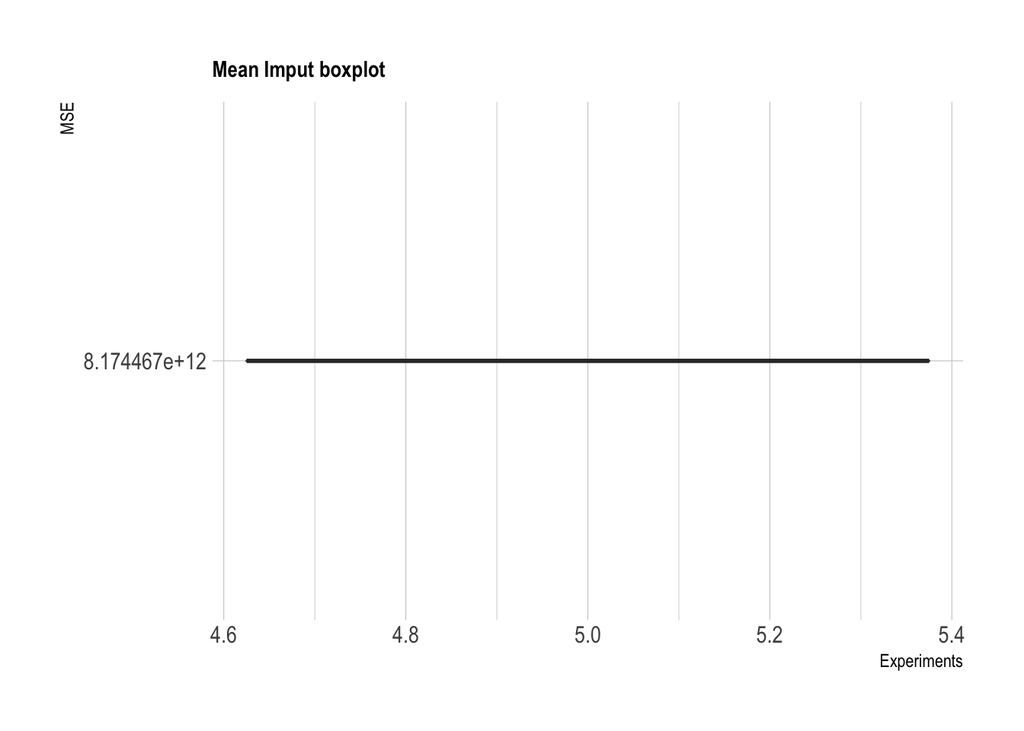

```r
# Libraries
library(tidyverse)
library(hrbrthemes)
library(viridis)



data %>%
  ggplot( aes(x=name, y=mean_impt, fill=name)) +
    geom_boxplot() +
    scale_fill_viridis(discrete = 0, alpha=0.6, option="A") +
    theme_ipsum() +
    theme(
      legend.position="none",
      plot.title = element_text(size=11)
    ) +
    ggtitle("Mean Imput boxplot") +
    xlab("Experiments")+ ylab("MSE")
```

#### 4.3 SOFT imputation Box-Plot

Plot the Soft imputation box-plot.

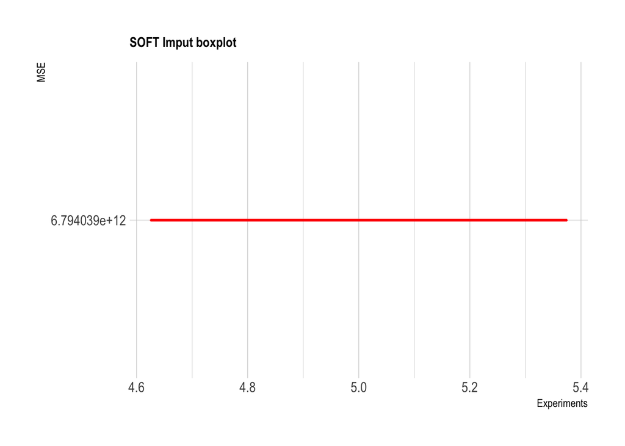

```r
data %>%
  ggplot( aes(x=name, y=soft_impt, fill=name)) +
    geom_boxplot(color="red", fill="orange") +
    scale_fill_viridis(discrete = 0, alpha=0.6, option="A") +

    theme_ipsum() +
    theme(
      legend.position="none",
      plot.title = element_text(size=11)
    ) +
    ggtitle("SOFT Imput boxplot") +
    xlab("Experiments")+ ylab("MSE")
```

#### 4.3 Multiple imputation Box-Plot

At the end, let’s plot the multiple imputation box-plot

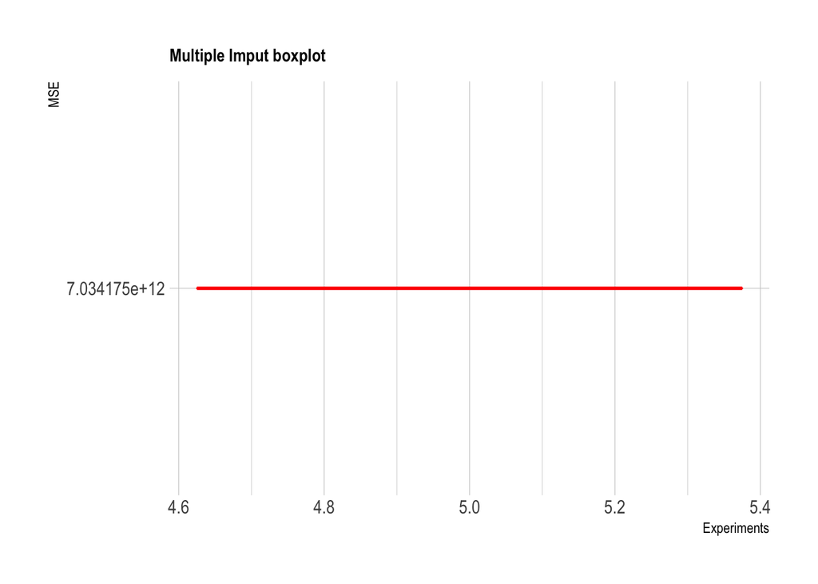

```r
data %>%
  ggplot( aes(x=name, y=multip_impt, fill=name)) +
    geom_boxplot(color="red", fill="purple") +
    scale_fill_viridis(discrete = 0, alpha=0.6, option="A") +

    theme_ipsum() +
    theme(
      legend.position="none",
      plot.title = element_text(size=11)
    ) +
    ggtitle("Multiple Imput boxplot") +
    xlab("Experiments")+ ylab("MSE")
```

# PART-2

## Question 1:

Let us consider an i.i.d. sample $(y_i,X_i)_{i=1,\dots,n}$.

$y_i\in \{0,1\}$ is the outcome variable, $X_i \in \mathbb{R}^d$ are the covariates, $\beta \in \mathbb{R}^d$ is the regression parameter.

We assume the logistic regression:
$$\mathbb{P}(y_i=1|X_i;\beta)=\frac{1}{1+\exp(-X_i^T\beta)}$$

In the sequel, we consider that $y$ contains some MCAR values and we derive an EM algorithm to estimate $\beta$.

**Write the observed log-likelihood. Note that in this case, we can maximize it with numerical methods (for example using the R function glm and argument family=binomial).**

## Solution 1:

The parameter to be estimated in the equation of a logistic regression is β vector.

To estimate β vector, we consider the N sample with labels either 0 or 1.

For samples labeled as ‘1’, we try to estimate β such that the product of all probability p(x) is as close to 1 as possible. And for samples labeled as ‘0’, we try to estimate β such that the product of all probability is as close to 0 as possible in other words (1 — p(x)) should be as close to 1 as possible.

This intuition is represented as

$$for\ samples\ labeled\ as\ 1:\prod_{s
\in y_i = 1}^{} p(x_i)$$
$$for\
samples\ labeled\ as\ 0: \prod_{s \in y_i = 0}^{} (1-
p(x_i))$$

On combining the above conditions we want to find β parameter such that the product of both of these products is maximum over all elements of the dataset.

$$L(\beta) = \prod_{s \in y_i = 1}^{}
p(x_i) * \prod_{s \in y_i = 0}^{} (1- p(x_i))$$

This function is the one we need to optimize and is called the likelihood function.

Now, We combine the products and take log-likelihood to simply it further

$$L(\beta) = \prod_{s}^{} p(x_i)^{y_i} *
(1- p(x_i))^{1- y_i}$$

$$l(\beta) = \sum_{i=1}^{n}
y_i log(p(x_i)) + \sum_{i=1}^{n} (1- y_i)log(1- p(x_i))$$
where $l(\beta)$ is the log-likelihood. We will call this likelihood as observed log-likelihood and use this symbol: $l_{obs}(\beta)$.

Let’s substitute p(x) with its exponent form

$$l_{obs}(\beta) = \sum_{i=1}^n y_i \log
\left(\frac{1}{1+\exp \left(-X_{i}^{T} \beta\right)}\right) + (1-y_i)
\log \left(1-\frac{1}{1+\exp \left(-X_{i}^{T}
\beta\right)}\right)$$

$$l_{obs}(\beta) = \sum_{i=1}^n y_i \log
\left(\frac{1}{1+\exp \left(-X_{i}^{T} \beta\right)}\right) + (1-y_i)
\log \left(\frac{exp \left(-X_{i}^{T} \beta\right)}{1+\exp
\left(-X_{i}^{T} \beta\right)}\right)$$

$$l_{obs}(\beta) = \sum_{i=1}^n y_i [ \log
\left(\frac{1}{1+\exp \left(-X_{i}^{T} \beta\right)}\right) - \log
\left(\frac{exp \left(-X_{i}^{T} \beta\right)}{1+\exp \left(-X_{i}^{T}
\beta\right)}\right) ]+ \log \left(\frac{exp \left(-X_{i}^{T}
\beta\right)}{1+\exp \left(-X_{i}^{T} \beta\right)}\right)$$

$$l_{obs}(\beta) = \sum_{i=1}^n y_i \beta
x_i + \log \left(\frac{1}{1+\exp \left(-X_{i}^{T}
\beta\right)}\right)$$

Now we end up with the final form of the log-likelihood function which is to be optimized:

$$l_{obs}(\beta) = \sum_{i=1}^n y_i \beta
x_i - \log \left(1+\exp \left(-X_{i}^{T}
\beta\right)\right)$$

## Question 2

**Although maximizing the observed likelihood can be done easily, we will also derive an EM algorithm to maximize it. Write the full log-likelihood.**

## Solution 2

We have a dataset with observed and missing values. The full log-likelihood in Logistic Regression model using this kind of data can be calculated with the joint probability of the both observed and missing data since we will be using both distributions. This joint probability can be represented as $P(y_i, R_i | X_i, \beta)$. Here the $R_i$ and the $\beta$ are covariates and the parameters to be estimated.

We need to calculate the log-likelihood of the all data points so we need to sum all these probabilities inside a log function, i.e:

$$L(\beta) = \sum_{i=1}^n \log \left(P(y_i, R_i | X_i, \beta)\right)$$

We need to put the joint probability that is given in Question 1:
$$\mathbb{P}(y_i=1|X_i;\beta)=\frac{1}{1+\exp(-X_i^T\beta)}$$

Now, we know how to full log-likelihood of the logistic regression. We combine the two formulas:
$$L(\beta) = \sum_{i=1}^{m} y_i (X_i^T \beta) - \log(1 + \exp(X_i^T
\beta)) + \sum_{i=m+1}^{n} \mathbb{P}(y_i = 1 \mid X_i, \beta)
\log\mathbb{P}(y_i = 1 \mid X_i, \beta) + (1-\mathbb{P}(y_i = 1 \mid
X_i, \beta)) \log(1-\mathbb{P}(y_i = 1 \mid X_i, \beta))$$

Where the first term is for observed samples and the second is for missing values. ,Later we will calculate the full log-likelihood using EM algorithm.

## Question 3:

**Show that the E-step can be written as follows**
$$Q\left(\beta ; \beta^{(r)}\right)=\sum_{i=1}^{n} Q_{i}\left(\beta ;
\beta^{(r)}\right)$$

where
$$Q_{i}\left(\beta ; \beta^{(r)}\right)= \begin{cases}\sum_{y_{i}
\in\{0,1\}} p\left(y_{i} \mid x_{i} ; \beta^{(r)}\right) \log
p\left(y_{i} \mid x_{i} ; \beta\right) & \text { if } y_{i} \text {
is missing } \\ \log p\left(y_{i} \mid x_{i} ; \beta\right) & \text
{ otherwise. }\end{cases}$$

## Solution 3:

There are two steps in the EM algorithm. The E-step basically calculates the expected full log-likelihood.

We found the full log-likelihood in the previous question and we will that again:
$$L(\beta) = \sum_{i=1}^n \log \left(P(y_i, R_i | X_i, \beta)\right)$$

Since it is a joint probability we can modify it like this:
$$= \sum_{i=1}^n \log \left(\mathbb{P}(y_i | X_i, \beta) P(R_i | y_i, X_i,
\beta)\right)$$

$$= \sum_{i=1}^n \log \left(\sum_{y_i \in {0,1}} P(y_i | X_i, \beta) P(R_i
| y_i, X_i, \beta)\right)$$

$$= \sum_{i=1}^n \sum_{y_i \in {0,1}} \mathbb{P}(y_i | X_i, \beta^{(r)})
\log \left(\mathbb{P}(y_i | X_i, \beta) \mathbb{P}(R_i | y_i, X_i,
\beta)\right)$$

Here we need to consider what is $R_i$. If the $R_i = 0$ then it will be eliminated since it is zero. Therefore we will be usingcase only where $R_i = 1$:

$$for\ samples\ where\ R_i = 1:P(R_i |
y_i, X_i, \beta) = 1$$
$$for\ samples\
where\ R_i = 0:P(R_i | y_i, X_i, \beta) = 0$$

So we can write the expected full log-likelihood as:

$$L(\beta) = \sum_{i=1}^n \sum_{y_i \in {0,1}}[R_i=1]P(y_i | X_i,
\beta^{(r)}) \log \left(P(y_i | X_i, \beta)\right)$$

Let’s remember the $Q\left(\beta ; \beta^{(r)}\right)$ function given in the question:

$$Q\left(\beta ; \beta^{(r)}\right)=\sum_{i=1}^{n} Q_{i}\left(\beta ;
\beta^{(r)}\right)$$

where

$$Q_{i}\left(\beta ; \beta^{(r)}\right)= \begin{cases}\sum_{y_{i}
\in\{0,1\}} p\left(y_{i} \mid x_{i} ; \beta^{(r)}\right) \log
p\left(y_{i} \mid x_{i} ; \beta\right) & \text { if } y_{i} \text {
is missing } \\ \log p\left(y_{i} \mid x_{i} ; \beta\right) & \text
{ otherwise. }\end{cases}$$

We arrived the same $Q\left(\beta ; \beta^{(r)}\right)$ function by calculating the expected full log-likelihood.

## Question 4:

## 4.1 Code the EM algorithm.

Hint 1: remark that $Q\left(\beta ; \beta^{(r)}\right)$ can be seen as a weighted complete data log-likelihood $\left(\sum_{i=1}^{n} \sum_{k=1}^{n_{i}} \omega_{y_{k}} \log p\left(y_{k} \mid x_{k} ; \beta\right)\right)$ based on a sample size $N=\sum_{i=1}^{n} n_{i}$, where $n_{i}=2$ if $y_{i}$ is missing and $n_{i}=1$ otherwise. The weights are $\omega_{y_{k}}=p\left(y_{k} \mid x_{k} ; \beta^{(r)}\right)$ if $y_{k}$ is missing and $\omega_{y_{k}}=1$ if $y_{k}$ is observed.

Hint 2: For the M-step, you can simply use the function glm with the argument weights.

```r
EM_algorithm <- function(data, labels) {
  #We will initialize the weights accroding to whether the missing data exists or not
  missing_data <- is.na(y)

  # calculate the initial weights
  weights <- ifelse(missing_data, 1/mean(missing_data), 1/(1-mean(missing_data)))

  #Let's initialize parameter estimator
  d= ncol(X)
  beta_hat <- rep(0, d )

  # EM algorithm
  for (i in 1:100) {
    #We will use the glm function here:
    EM_result <- glm(y ~ X, family = binomial(), data = data.frame(X, y), weights = weights)
    #Define the new beta estimator
    beta_hat_new <- coef(EM_result)

    #If the difference between the beta_hat and the new beta_hat is less than a threshold(1e-5 in this case), then break. Else, we update the beta_hat:
    if (max(abs(beta_hat_new - beta_hat)) < 1e-5) {
      break}

    #Update beta_hat:
    beta_hat <- beta_hat_new
  }

  return(beta_hat)
}
```

## 4.2 Apply the EM algorithm for the synthetic data defined below.

Compare the following estimators for β by computing the MSE: (i) without missing values (y, X), (ii) with missing values (yNA, X) by using only the rows which do not contain missing values, (iii) with missing values (yNA, X) by using the EM algorithm. Note that in (i) and (ii), you just have to use the function glm. Here, you can consider that the intercept is null. What do we notice for estimators (ii) and (iii) ?

#### Create dataset to use it in EM:

First we create the dataset. This part was given in the Homework pdf.

```r
library(mvtnorm)
set.seed(1)
d <- 3
beta_true <- c(0.1,0.5,0.9)
n <- 1000
mu <- rep(0,d)
Sigma <- diag(1,d)+matrix(0.5,d,d)
X <- rmvnorm(n, mean=mu, sigma=Sigma) #multivariate Gaussian variable
logit_link <- 1/(1+exp(-X%*%beta_true))
y <- (runif(n)<logit_link)*1
#### Introduction of MCAR values
nb_missingvalues <- 0.3*n*d

missing_idx <- sample(1:n,nb_missingvalues)
yna <- y
yna[missing_idx] <- NA
```

### (i) without missing values (y, X)

Above we define missing values in y that is called yna. Since the questions asks for non-missing values, we will use only y.

```r
result_i <- EM_algorithm(X, y)
result_i
```

```
## (Intercept)          X1          X2          X3
##  -0.1388754   0.1441317   0.4606494   1.0372818
```

### (ii) with missing values (yNA, X) by using only the rows which do not contain missing values

I didn’t get this question very well. With missing values by only using rows that don’t contain missing values? As I understand correctly, we need to remove the rows that have missing values in both X and y. Then run the EM.

```r
#yna has the missing values. So we need to check yna to detect missing values:
no_missing <- !is.na(yna)
#Then we only take the parts where there is no missing value in X and y
X_no_missing <- X[no_missing,]
y_no_missing <- yna[no_missing]

#Run the EM
result_ii <- EM_algorithm(X_no_missing, y_no_missing)
result_ii
```

```
## (Intercept)          X1          X2          X3
##  -0.1388754   0.1441317   0.4606494   1.0372818
```

### (iii) with missing values (yNA, X)

I think here we need to use the yna and X without removing any missing values:

```r
result_iii <- EM_algorithm(X, yna)
result_iii
```

```
## (Intercept)          X1          X2          X3
##  -0.1388754   0.1441317   0.4606494   1.0372818
```

As we did in the PART-1 of this homework, we can compare the MSE of our estimators and decide which one works better. I defined the MSE function in the PART-1, therefore I will use it directly.

```r
MSE <- function(X1, X2){

  return(mean( (X1 - X2)^2 ,na.rm=T)^2 )

  }
```

```r
MSE_result_i = MSE(result_i, beta_true)
MSE_result_i
```

```
## [1] 0.09847511
```

```r
MSE_result_ii = MSE(result_ii, beta_true)
MSE_result_ii
```

```
## [1] 0.09847511
```

```r
MSE_result_iii = MSE(result_iii, beta_true)
MSE_result_iii
```

```
## [1] 0.09847511
```

- **What do we notice for estimators (ii) and (iii)**

The estimators for (ii) and (iii) are same. Also the MSE are same.

## 4.2 Apply the EM algorithm for the cancer prostate dataset (only quantitative variables) and compare the different estimators for $\beta$. Here, consider that the intercept is not null.

```r
set.seed(3)

#Load the dataset
cancer_data <- read.table(file = 'cancerprostate.csv',header = T, sep = ";")
#Define the beta_true again
beta_true <- c(0.1,0.5,0.9)
#Eliminate the string feautres
X <- data.frame(cancer_data, stringsAsFactors = 0)
y <- cancer_data$Y
#Apply the EM
#We will write to the glm algorithm's first parameter as [y ~ column_names]
result <- glm(y ~ age + acide + rayonx + taille + log.acid, family = binomial(), data = X)
beta_hat<- coef(result)

#result = EM_algorithm(X, y)
cancer_mse <- MSE(beta_hat, beta_true)
cancer_mse
```

```
## [1] 2031.125
```

MSE of the cancer dataset is pretty high(2031,125)

## 4.3 Briefly discuss the link with semi-supervised learning

The Expectation-Maximization (EM) algorithm is a technique for finding maximum likelihood estimates of parameters in statistical models, where the data may be incomplete or have missing values. In the context of semi-supervised learning, EM can be used to estimate the parameters of a model when only a portion of the data is labeled.

The EM algorithm works by alternating between two steps: the expectation step (E-step), where the missing data is estimated based on the current parameter estimates, and the maximization step (M-step), where the parameters are updated based on the estimated missing data.

In semi-supervised learning, the EM algorithm can be used to estimate the parameters of a model when only a portion of the data is labeled. The labeled data is used in the M-step to update the model parameters, while the unlabeled data is used in the E-step to estimate the missing labels, which are then used in the M-step to further update the model parameters. This process is repeated until the model parameters converge.

In this way, the EM algorithm can be used to leverage the information in both labeled and unlabeled data to improve the performance of the model, which is particularly useful in situations where labeled data is scarce.